# End-to-end NanoBRET analysis protocol

Thiago Loreto Matos

Pharmacogenetics Laboratory, Drug Research and Development Center, Department of Physiology and Pharmacology, Federal University of Ceará, Fortaleza, 60430-160, Brazil

thiago-loreto@hotmail.com

2026-09-05

#### Package

dosefitr 1.0.0

# 1 Introduction

This vignette is an end-to-end **NanoBRET analysis protocol**, written as a working template you can adapt to your own experiments. Each stage of the analysis is a separate topic: one short prose block explaining what the step does and how to change it for your project, followed by a code block that runs against the two bundled example plates.

The walkthrough mirrors the pattern of a real-world `dosefitr` session: locate the raw data, build the ratio table, detect outliers, fit the dose-response curves, save the plots, compare across plates, and export the results (the batch functions write their own result workbooks, with an optional Scarab-format submission table for labs that use it). Where a step has a common variation (v2 ratio processor, viability pipeline, replicate merging), that variation is treated as its own sub-topic instead of being folded into the main flow.

For an overview of the package and a comparison with other CRAN and Bioconductor dose-response packages, see `vignette("dosefitr", package = "dosefitr")`. For a per-function walkthrough of the NanoBRET pipeline, see `vignette("dosefitr-nanobret", package = "dosefitr")`. For the single-channel viability pipeline, see `vignette("dosefitr-viability", package = "dosefitr")`.

# 2 Install and load

Install the release version from Bioconductor once accepted:

```r
if (!require("BiocManager", quietly = TRUE))
    install.packages("BiocManager")
BiocManager::install("dosefitr")
```

Or install the in-development version from GitHub:

```r
# install.packages("remotes")
remotes::install_github("AKKDataAnalysis/dosefitr")
```

Load the package:

```r
library(dosefitr)
```

# 3 Point at your data

`batch_ratio_analysis()` scans a directory for plate files that match a regular expression, together with a single Excel info table that maps each plate-row to a compound. Everything downstream builds on the object that this function returns.

The package ships two example NanoBRET plates plus an info table under `inst/extdata/`. To keep this vignette compliant with the “no writes outside `tempdir()`” rule, we stage those files into a working directory under `tempdir()`:

```r
extdata_dir <- system.file("extdata", package = "dosefitr")
work_dir    <- file.path(tempdir(), "dosefitr_protocol")
dir.create(work_dir, showWarnings = FALSE, recursive = TRUE)

invisible(file.copy(
    from      = list.files(extdata_dir, pattern = "^nanobret_",
                           full.names = TRUE),
    to        = work_dir,
    overwrite = TRUE
))

list.files(work_dir)
```

```
#> [1] "nanobret_info.xlsx"     "nanobret_plate_01.xlsx" "nanobret_plate_02.xlsx"
```

**In your own project.** Skip the copy-to-tempdir step and pass the path to your data folder as the `directory` argument to `batch_ratio_analysis()` below (for example, `directory = "C:/path/to/your/dataset"`).

# 4 Compute BRET ratios (v1)

`batch_ratio_analysis()` reads each plate’s donor and acceptor channels, computes the BRET ratio per well as `(acceptor / donor) * 1000`, and processes each compound row against the plate’s 0 % and 100 % controls. The result is a named list, one entry per plate, keyed by the info-table sheet name.

The example call below uses the bundled data’s layout (controls at columns 1 and 24) and passes `low_value_threshold = 3000`, which flags wells whose donor channel falls below 3000 counts as unreliable. On the bundled data no wells fall below that floor, so no wells are flagged – but the argument is included to demonstrate the pattern.

```r
ratio_out <- file.path(tempdir(), "dosefitr_protocol_ratio")
dir.create(ratio_out, showWarnings = FALSE)

ratio_res <- batch_ratio_analysis(
    directory           = work_dir,
    info_file           = "nanobret_info.xlsx",
    data_pattern        = "nanobret_plate_\\d+\\.xlsx$",
    control_0perc       = "1",
    control_100perc     = "24",
    selected_columns    = 1:24,
    low_value_threshold = 3000,
    generate_reports    = FALSE,
    output_dir          = ratio_out,
    verbose             = FALSE
)

names(ratio_res)
```

```
#> [1] "plate_01" "plate_02"
```

```r
mrt <- ratio_res$plate_01$result$modified_ratio_table
dim(mrt)
```

```
#> [1] 13 33
```

```r
head(mrt[, 1:5], 6)
```

```
#>   log(inhibitor).[M] KinaseA:Cpd1 KinaseA:Cpd1.2 KinaseA:Cpd2 KinaseA:Cpd2.2
#> 1                 NA    440.60473      440.60473    440.60473      440.60473
#> 2              -4.61     57.77871       60.26671     49.53919       54.08118
#> 3              -5.13     73.78084       70.48321     56.15228       60.14455
#> 4              -5.61     98.96811      115.34193     74.37310       78.36705
#> 5              -6.13    172.31550      176.22107    139.43796      142.79831
#> 6              -6.61    265.00617      308.53165    216.65074      227.51707
```

**In your own project.** The three arguments most likely to differ between plates are:

- `control_0perc` – which column holds the 0 % control (baseline).
- `control_100perc` – which column holds the 100 % control (saturated).
- `selected_columns` – which columns to include in the analysis.

For example, if your DMSO baseline is in column 24 and your saturated compound is in column 12:

```r
ratio_res <- batch_ratio_analysis(
    directory           = "C:/path/to/your/dataset",
    control_0perc       = 24,
    control_100perc     = 12,
    low_value_threshold = 3000,
    output_dir          = "./drc_quality",
    verbose             = TRUE
)
```

# 5 Compute BRET ratios (v2 processor)

The v2 processor handles two layouts the v1 processor does not:

1. **Info tables with merged control cells** – the info sheet has a merged control block instead of one row per control column.
2. **Multiple 100 % control columns** – `control_100perc` is a *vector* of column indices (for example, when the saturated-compound wells are duplicated across two columns).

Switch on the v2 processor by passing `function_version = "v2"`. The snippet below shows the pattern; it does not run because the bundled info table follows the v1 layout:

```r
ratio_res_v2 <- batch_ratio_analysis(
    directory           = "C:/path/to/your/dataset",
    control_0perc       = 16,
    control_100perc     = c(12, 24),
    low_value_threshold = 3000,
    function_version    = "v2",
    output_dir          = "./drc_quality",
    verbose             = TRUE
)
```

The cell-viability pipeline has its own `version = "v2"` processor that borrows this same NanoBRET-style control model (a fixed 0 % scalar plus one or more averaged 100 % columns); see `vignette("dosefitr-viability", package = "dosefitr")` for a viability-side example and for the row-based `version = "v3"` layout.

# 6 Detect outliers (ROUT)

You have a choice at this step: feed the raw `ratio_res` into the DRC fitter and let the fitter see every point, or feed the ROUT-cleaned `rout_res` and drop the outliers before fitting. Both are valid; the outlier report is useful either way for QC.

```r
rout_res <- rout_outliers_batch(ratio_res, Q = 0.01, verbose = FALSE)

nrow(rout_res$outlier_summary)
```

```
#> [1] 33
```

```r
head(rout_res$outlier_summary, 5)
```

```
#>      plate     compound         column replicate row log10_conc bret_ratio
#> 1 plate_01 KinaseA:Cpd1   KinaseA:Cpd1         1  11      -8.91   496.3071
#> 2 plate_01 KinaseA:Cpd2   KinaseA:Cpd2         1  11      -8.91   261.0834
#> 3 plate_01 KinaseA:Cpd2 KinaseA:Cpd2.2         2  11      -8.91   238.7008
#> 4 plate_01 KinaseA:Cpd3   KinaseA:Cpd3         1  11      -8.91   228.4345
#> 5 plate_01 KinaseA:Cpd3 KinaseA:Cpd3.2         2  11      -8.91   224.4356
#>     fitted std_residual dynamic_range_pct
#> 1 428.0655        5.264             612.9
#> 2 451.9570       -8.165             798.9
#> 3 451.9570       -9.122             798.9
#> 4 458.8474      -12.099             754.5
#> 5 458.8474      -12.309             754.5
```

Overlay the flagged wells on the fitted curves for a visual sanity check:

```r
pobc_out <- file.path(tempdir(), "dosefitr_protocol_pobc")
dir.create(pobc_out, showWarnings = FALSE)

pobc_res <- plot_outliers_batch_curves(
    rout_res,
    plates     = "plate_01",
    output_dir = pobc_out,
    verbose    = FALSE
)
```

# 7 Merge replicate plates (optional)

If the same 384-well layout was run on separate days or with different compound batches, `merge_plate_replicates()` combines the per-plate tables into a single wide table with all replicate columns side-by-side. Bridging compounds (present on both plates) end up with four replicate columns instead of two.

```r
merge_out <- file.path(tempdir(), "dosefitr_protocol_merge")
dir.create(merge_out, showWarnings = FALSE)

merged_res <- merge_plate_replicates(
    ratio_res,
    output_dir       = merge_out,
    generate_reports = FALSE
)
```

```
#> ============================================================
#> MERGE PLATE REPLICATES
#> ============================================================
#> Plates to merge  : plate_01, plate_02
#> Merged name      : merged
#> Concentration col: log(inhibitor).[M]
#> ------------------------------------------------------------
#> Unique compounds : 28
#>   plate_01            : 32 column(s), 16 unique compound(s)
#>   plate_02            : 32 column(s), 16 unique compound(s)
#> ------------------------------------------------------------
#> Merged table     : 13 rows x 65 columns (64 data columns)
#> Replicates per compound:
#>   KinaseA:Cpd1                            : 4 replicate(s)
#>   KinaseA:Cpd2                            : 2 replicate(s)
#>   KinaseA:Cpd3                            : 2 replicate(s)
#>   KinaseA:Cpd4                            : 2 replicate(s)
#>   KinaseA:Cpd5                            : 4 replicate(s)
#>   KinaseA:Cpd6                            : 2 replicate(s)
#>   KinaseA:Cpd7                            : 2 replicate(s)
#>   KinaseB:Cpd10                           : 2 replicate(s)
#>   KinaseB:Cpd11                           : 2 replicate(s)
#>   KinaseB:Cpd12                           : 2 replicate(s)
#>   KinaseB:Cpd13                           : 4 replicate(s)
#>   KinaseB:Cpd8                            : 2 replicate(s)
#>   KinaseB:Cpd9                            : 4 replicate(s)
#>   KinaseC:Cpd14                           : 2 replicate(s)
#>   KinaseC:Cpd15                           : 2 replicate(s)
#>   KinaseC:Cpd16                           : 2 replicate(s)
#>   KinaseD:Cpd17                           : 2 replicate(s)
#>   KinaseD:Cpd18                           : 2 replicate(s)
#>   KinaseD:Cpd19                           : 2 replicate(s)
#>   KinaseD:Cpd20                           : 2 replicate(s)
#>   KinaseD:Cpd21                           : 2 replicate(s)
#>   KinaseD:Cpd22                           : 2 replicate(s)
#>   KinaseD:Cpd23                           : 2 replicate(s)
#>   KinaseD:Cpd24                           : 2 replicate(s)
#>   KinaseD:Cpd25                           : 2 replicate(s)
#>   KinaseD:Cpd26                           : 2 replicate(s)
#>   KinaseD:Cpd27                           : 2 replicate(s)
#>   KinaseD:Cpd28                           : 2 replicate(s)
#> ============================================================
```

```r
names(merged_res)
```

```
#> [1] "merged"
```

```r
merged_mrt <- merged_res[[1]]$result$modified_ratio_table
dim(merged_mrt)
```

```
#> [1] 13 65
```

```r
head(colnames(merged_mrt), 8)
```

```
#> [1] "log(inhibitor).[M]" "KinaseA:Cpd1"       "KinaseA:Cpd1.2"
#> [4] "KinaseA:Cpd1.3"     "KinaseA:Cpd1.4"     "KinaseA:Cpd2"
#> [7] "KinaseA:Cpd2.2"     "KinaseA:Cpd3"
```

Compounds that appear on only one plate keep their two-replicate columns; compounds that appear on both plates gain four columns (`Cpd1`, `Cpd1.2`, `Cpd1.3`, `Cpd1.4`).

# 8 Fit dose-response curves (4PL / 3PL)

`batch_drc_analysis()` fits every compound with a 3- or 4-parameter logistic model, using the `OptimModel`-based solver with assay-aware plausibility limits on Bottom, Top, and Hill-slope. Each fit is labelled with a `Curve_Quality` tag (`Good curve`, `Wide LogIC50/LogEC50 CI range`, `Top too low`, `Bottom too high`, …) that summarises the fit’s health.

## 8.1 `model = "3pl"` or `"4pl"`?

The 3PL model fixes the Hill slope to 1 and estimates only Bottom, Top, and LogIC50/LogEC50. The 4PL model additionally estimates the Hill slope. Use 3PL when you want a standard, comparable IC50 across many compounds and you have no strong prior evidence for cooperative binding; use 4PL when the slope itself is a parameter you care about, or when several compounds visibly show slopes far from 1.

## 8.2 `normalize = TRUE` or `normalize = FALSE`?

For **NanoBRET** you can fit either the raw control-normalised ratio table (`normalize = FALSE`) or re-scale the fit output to a 0 - 100 % inhibition axis inside the fitter (`normalize = TRUE`). Both give the same `LogIC50/LogEC50` – the difference is only whether the reported Bottom and Top are in ratio units or in percent. `normalize = TRUE` is the more Prism-like presentation; `normalize = FALSE` keeps the numbers on the original BRET-ratio scale.

For **viability** the recommended default is `normalize = TRUE`, which clamps the fit to the 0 - 100 % viability window; see `vignette("dosefitr-viability", package = "dosefitr")`.

```r
drc_out <- file.path(tempdir(), "dosefitr_protocol_drc")
dir.create(drc_out, showWarnings = FALSE)

drc_res <- batch_drc_analysis(
    batch_results    = rout_res,
    model            = "3pl",
    normalize        = TRUE,
    output_dir       = drc_out,
    generate_reports = FALSE,
    verbose          = FALSE
)

sum_01 <- drc_res$drc_results$plate_01$drc_result$summary_table
sum_01[, c("Compound", "LogIC50/LogEC50", "R_squared", "Curve_Quality")]
```

```
#>               Compound LogIC50/LogEC50 R_squared Curve_Quality
#> Top...1   KinaseA:Cpd1          -6.423     0.991    Good curve
#> Top...2   KinaseA:Cpd2          -6.635     0.986    Good curve
#> Top...3   KinaseA:Cpd3          -6.913     0.994    Good curve
#> Top...4   KinaseA:Cpd4          -6.949     0.997    Good curve
#> Top...5   KinaseA:Cpd5          -7.145     0.994    Good curve
#> Top...6   KinaseA:Cpd6          -7.354     0.984    Good curve
#> Top...7   KinaseA:Cpd7          -7.479     0.989    Good curve
#> Top...8   KinaseB:Cpd8          -6.885     0.986    Good curve
#> Top...9   KinaseB:Cpd9          -7.145     0.985    Good curve
#> Top...10 KinaseB:Cpd10          -7.173     0.991    Good curve
#> Top...11 KinaseB:Cpd11          -7.541     0.995    Good curve
#> Top...12 KinaseB:Cpd12          -7.764     0.995    Good curve
#> Top...13 KinaseB:Cpd13          -8.053     0.997    Good curve
#> Top...14 KinaseC:Cpd14          -5.932     0.989    Good curve
#> Top...15 KinaseC:Cpd15          -6.180     0.967    Good curve
#> Top...16 KinaseC:Cpd16          -6.425     0.982    Good curve
```

**In your own project.** Switch `model` to `"4pl"` if you want a free-Hill fit. Set `normalize = FALSE` if you would rather see the fit on the raw BRET-ratio scale. If you skipped the ROUT step above, pass `ratio_res` directly instead of `rout_res`.

# 9 Save all dose-response plots

`batch_save_all_drc_plots()` writes one PNG per compound plus (optionally) a combined patchwork panel per plate. Filenames encode the plate and `construct:compound` key, so a plate of 16 compounds becomes 16 PNGs (or 32 across two plates).

```r
plots_out <- file.path(tempdir(), "dosefitr_protocol_plots")
dir.create(plots_out, showWarnings = FALSE)

save_res <- batch_save_all_drc_plots(
    batch_drc_results = drc_res,
    output_dir        = plots_out,
    dpi               = 72,
    save_panel        = FALSE,
    verbose           = FALSE
)

length(list.files(plots_out, recursive = TRUE, pattern = "\\.png$"))
```

```
#> [1] 32
```

**In your own project.** For large batches, narrow the output with `plates_to_plot` (character vector of plate names) or `compounds_to_plot` (character vector of compound suffixes – the part after `:` in the compound key). Set `save_panel = TRUE` to also emit a combined per-plate panel figure.

# 10 Overlay multiple compounds

[figure not shown]

```r
overlay <- plot_multiple_compounds(
    drc_res,
    compound_indices  = 1:6,
    plate             = "plate_01",
    color_palette     = "colorblind",
    plot_title        = "",
    legend_text_size  = 12,
    axis_text_size    = 11,
    axis_title_size   = 12,
    save_plot         = NULL,
    verbose           = FALSE
)
```

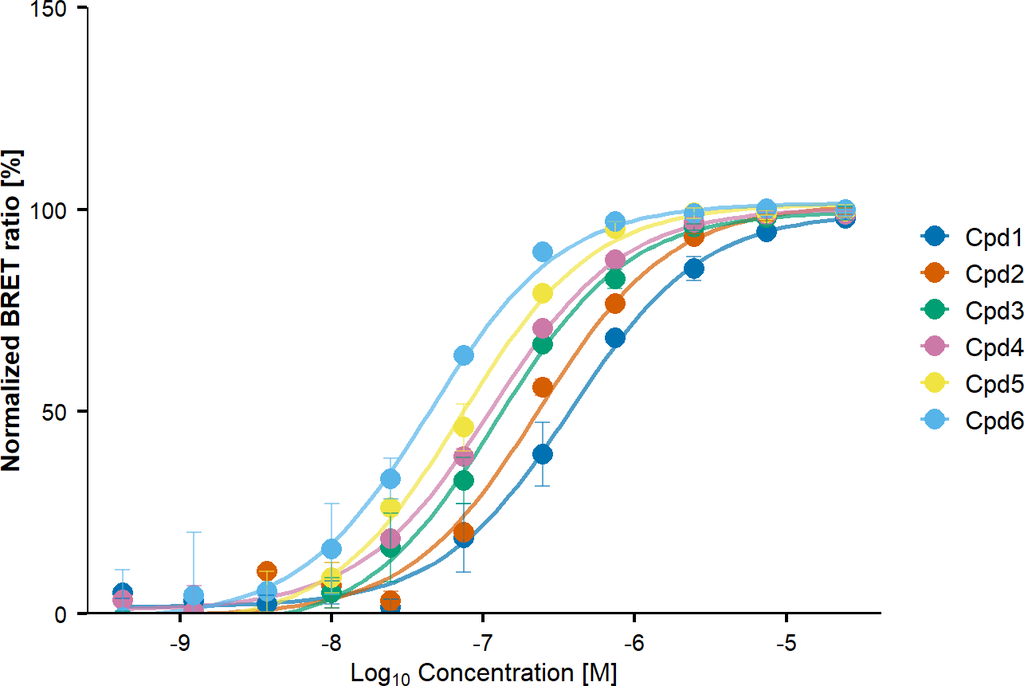

```r
overlay
```

**In your own project.** Replace `compound_indices` with the row indices you want to overlay (the same order as in `drc_res$..$summary_table`). Pass `save_plot = TRUE` to auto-save the plot under the plate’s DRC output directory, or a file path to save with an explicit name.

# 11 Compare compounds across plates

`compare_plates_drc()` matches compounds across plates (via `compare_by = "compound"`) or targets across plates (via `compare_by = "construct"`) and produces side-by-side fits for each match. It is the standard cross-plate consistency check.

The two bundled plates share four “bridging” compounds (`Cpd1`, `Cpd5`, `Cpd9`, and `Cpd13`). We compare a two-compound subset to keep the output small. Because `compare_by = "compound"`, `selected_entities` receives compound names only (without the construct prefix):

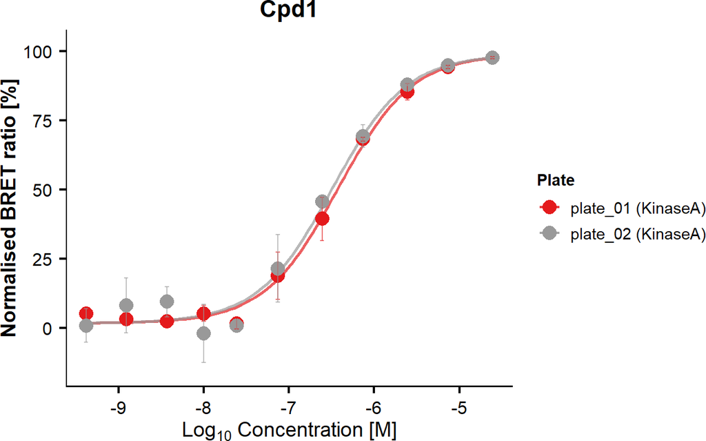

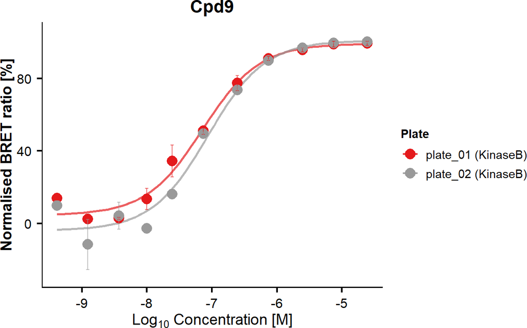

```r
cmp_out <- file.path(tempdir(), "dosefitr_protocol_cmp")
dir.create(cmp_out, showWarnings = FALSE)

cmp_res <- compare_plates_drc(
    drc_res,
    compare_by        = "compound",
    selected_entities = c("Cpd1", "Cpd9"),
    min_plates        = 2,
    output_dir        = cmp_out,
    plot_dpi          = 72,
    verbose           = FALSE
)
```

```r
length(cmp_res)
```

```
#> [1] 2
```

```r
names(cmp_res)
```

```
#> [1] "Cpd1" "Cpd9"
```

**In your own project.** Drop `selected_entities` to compare every bridging compound. Use `compare_by = "construct"` when you want the same target aggregated across plates (useful for tracking compound libraries against a single kinase across weeks of screening). To preserve the original one-plot-per-pair behavior, use `compare_by = "construct_compound"`; in that mode, entity names have the form `"KinaseA:Cpd1"`.

# 12 Build the Scarab table (optional, lab-specific)

This step is optional and specific to laboratories that submit to the SGC Scarab system. The standard results have already been written by the batch functions (`batch_ratio_analysis()` and `batch_drc_analysis()` write their result workbooks and a consolidated report when `generate_reports = TRUE`), so you only need this if you require a Scarab-format submission file.

`scarab_table()` produces a Scarab-format submission table: one long sheet with fitted parameters, quality metrics, and experiment metadata side-by-side. The metadata block encodes information a curator needs to reproduce the analysis (date, experimenter, tracer identity and concentration, nLuc orientation, decimal-separator convention).

The values below are illustrative – supply your own for each experiment.

```r
scarab <- scarab_table(
    ratio_res, drc_res,
    plate_name                 = "plate_01",
    date                       = "240101",
    experimenter_abbrev        = "ME",
    nLuc_orientation           = "C",
    tracer_kd_app              = -7.5,
    tracer_concentration_used  = -7.5,
    tracer                     = "Tracer K10",
    decimal_separator          = ","
)

dim(scarab)
```

```
#> [1] 76 17
```

```r
head(scarab[, 1:5], 6)
```

```
#>                            Field                     X4                     X5
#> 1                         Kinase                KinaseA                KinaseA
#> 2               nLuc Orientation                      C                      C
#> 3                       Compound                   Cpd1                   Cpd2
#> 4 Experiment Type (lysed/intact)            intact mode            intact mode
#> 5                  Experiment ID 240101-ME-KinaseA-Cpd1 240101-ME-KinaseA-Cpd2
#> 6                      Cell line                HEK293T                HEK293T
#>                       X6                     X7
#> 1                KinaseA                KinaseA
#> 2                      C                      C
#> 3                   Cpd3                   Cpd4
#> 4            intact mode            intact mode
#> 5 240101-ME-KinaseA-Cpd3 240101-ME-KinaseA-Cpd4
#> 6                HEK293T                HEK293T
```

**In your own project.** Set `decimal_separator = "."` if your Scarab instance expects US-style decimals. Set `nLuc_orientation` to `"N"` for N-terminal fusion constructs. `date` is a free-form character string using the convention your team already uses (here `YYMMDD`).

# 13 Cell viability sidebar

The same plate layout can carry a single-channel viability readout (e.g. CellTiter-Glo). Substitute `batch_viability_analysis()` for `batch_ratio_analysis()` and pass `normalize = TRUE` to the DRC step:

```r
via_res <- batch_viability_analysis(
    directory        = "C:/path/to/your/dataset",
    control_0perc    = 13,
    control_100perc  = 12,
    selected_columns = c(2:23),
    output_dir       = "./drc_quality",
    verbose          = TRUE
)

drc_res_via <- batch_drc_analysis(
    batch_results = via_res,
    model         = "3pl",
    normalize     = TRUE,
    output_dir    = "./drc_results",
    verbose       = TRUE
)
```

For a runnable end-to-end viability example, see `vignette("dosefitr-viability", package = "dosefitr")`.

# 14 Sanity check

For the bundled plates you should see 16/16 successful fits per plate and mostly `Good curve` labels. If your own analysis shows many failures, first check that `control_0perc` and `control_100perc` match your actual plate layout – a mis-specified control column is the single most common source of failed fits.